# Evaluation du 10 mars 2022

M. Blondeau

10/03/2022

```r
library(sf)
```

On charge la librairie sf.

```r
zone <- st_read("vote.gpkg", "zone")
str(zone)
```

```
## Classes 'sf' and 'data.frame':   32 obs. of  6 variables:
##  $ Layer     : chr  "_Bureau 32" "_Bureau 24" "_Bureau 15" "_Bureau 14" ...
##  $ bureauNo_1: chr  NA "ECOLE ELEMENTAIRE OLYMPE DE GOUGES" "SALLE MAURICE PETITJEAN" "ECOLE MATERNELLE LEO LAGRANGE" ...
##  $ aire      : int  129558 260846 253109 229099 104115 230670 54899 91995 70288 140443 ...
##  $ numBureau : int  32 24 15 14 12 30 5 9 28 26 ...
##  $ txVotants : int  NA 50 41 53 55 54 46 50 66 52 ...
##  $ geom      :sfc_MULTIPOLYGON of length 32; first list element: List of 1
##   ..$ :List of 1
##   .. ..$ : num [1:21, 1:2] 662713 662894 662926 663008 662925 ...
##   ..- attr(*, "class")= chr [1:3] "XY" "MULTIPOLYGON" "sfg"
##  - attr(*, "sf_column")= chr "geom"
##  - attr(*, "agr")= Factor w/ 3 levels "constant","aggregate",..: NA NA NA NA NA
##   ..- attr(*, "names")= chr [1:5] "Layer" "bureauNo_1" "aire" "numBureau" ...
```

Je lis le fichier vote.gpkg et je regarde sa structure.

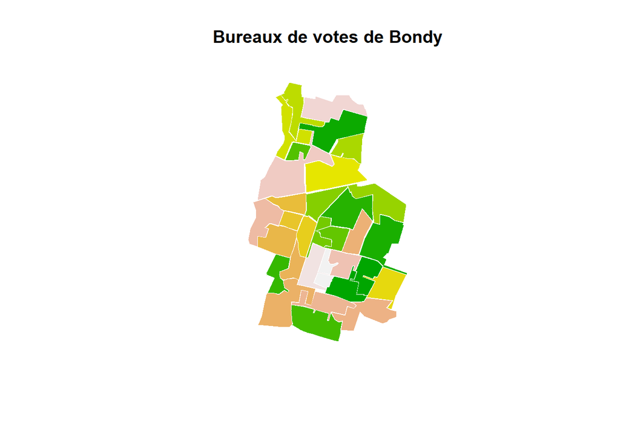

```r
plot(zone$geom, col = terrain.colors (31),
  border = NA,
  main = "Bureaux de votes de Bondy")
```

On fait ici apparaître les bureaux de vote de Bondy, en nommant la carte qui apparaît “Bureaux de vote de Bondy” avec ‘main’ qui permet de donner un titre à ce que nous produisons, et ‘border = NA’ qui permet de supprimer les lignes noires qui délimitait les différentes parties de la carte.

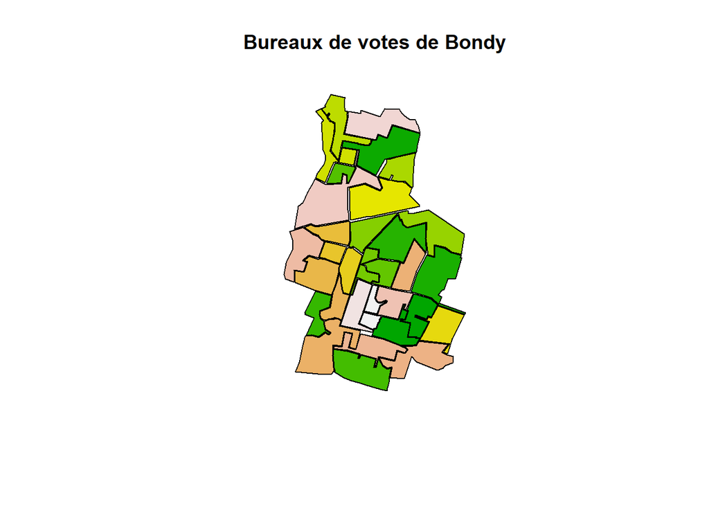

```r
plot(zone$geom, col = terrain.colors (31),
  main = "Bureaux de votes de Bondy")
```

Ici, la même carte mais avec la commande ‘border = NA’ supprimée, ce qui rajoute les lignes noires qui délimitent les différents bureaux de votes de la ville.

```r
union_bureau <- st_union(zone)
union_bureau
```

```
## Geometry set for 1 feature
## Geometry type: MULTIPOLYGON
## Dimension:     XY
## Bounding box:  xmin: 661088.1 ymin: 6865338 xmax: 663354.7 ymax: 6869043
## Projected CRS: RGF93 / Lambert-93
```

```
## MULTIPOLYGON (((661932.2 6865464, 661878 686548...
```

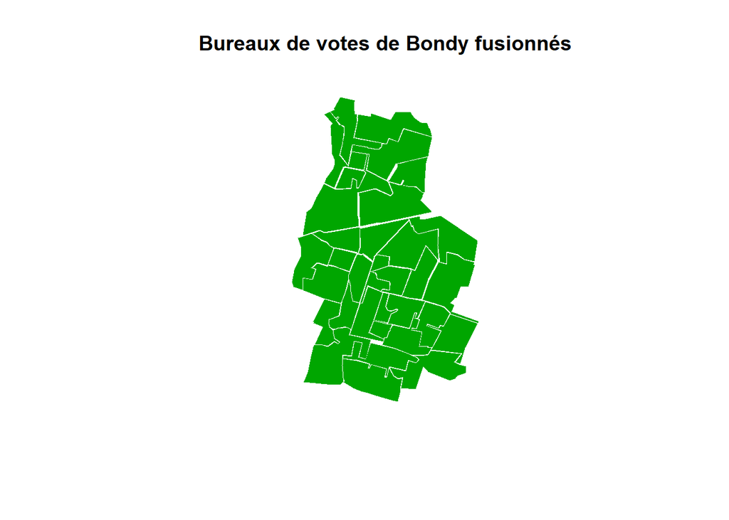

```r
plot(union_bureau, col = terrain.colors (31),
  border = NA,
  main = "Bureaux de votes de Bondy fusionnés")
```

J’ai ici fusionné les bureaux de vote qui étaient des multipolygones en un seul, et ai à nouveau supprimé les lignes noires de délimitations.

```r
setwd("C:/Users/Marion/Downloads/Exam_SIG")
read.csv("bondyInsee.csv", fileEncoding = "UTF-8")
```

[output not shown]

[output cut: 1308 more lines]

```r
data <- read.csv("bondyInsee.csv", fileEncoding = "UTF-8")
```

Je m’assure d’abord que je suis toujours dans le même fichier avec setwd (je n’en étais plus sûre à cause d’une erreur affichée dans la console), puis j’ajoute le fichier bondyInsee.csv, en l’encodant pour que les accents soient bien traduits.

```r
str(data)
```

```
## 'data.frame':    188 obs. of  43 variables:
##  $ X         : int  55708 55715 55725 55732 55752 55753 55758 55813 55825 55836 ...
##  $ IdINSPIRE : chr  "CRS3035RES200mN2892800E3771800" "CRS3035RES200mN2892800E3770600" "CRS3035RES200mN2892800E3771400" "CRS3035RES200mN2892000E3770600" ...
##  $ Id_carr1km: chr  "CRS3035RES1000mN2892000E3771000" "CRS3035RES1000mN2892000E3770000" "CRS3035RES1000mN2892000E3771000" "CRS3035RES1000mN2892000E3770000" ...
##  $ I_est_cr  : int  0 0 0 0 0 0 0 0 0 0 ...
##  $ Id_carr_n : chr  "CRS3035RES200mN2892800E3771800" "CRS3035RES1000mN2892000E3770000" "CRS3035RES200mN2892800E3771400" "CRS3035RES1000mN2892000E3770000" ...
##  $ Groupe    : int  866428 866396 866443 866383 866447 866440 866400 866398 866402 866435 ...
##  $ Depcom    : int  93057 93010 93010 93010 93010 93010 93010 93010 93010 93077 ...
##  $ I_pauv    : int  0 0 0 0 0 0 0 0 0 0 ...
##  $ Id_car2010: chr  "CRS3035RES200mN2892800E3771800" "CRS3035RES200mN2892800E3770600" "CRS3035RES200mN2892800E3771400" "CRS3035RES200mN2892000E3770600" ...
##  $ Ind       : num  125 426 454 82 460 ...
##  $ Men       : num  49 178 142 29 167 135 232 188 294 72 ...
##  $ Men_pauv  : num  5 27 22 1 32 33 43 23 61 11 ...
##  $ Men_1ind  : num  14 59 23 4 43 36 92 62 99 11 ...
##  $ Men_5ind  : num  4 19 25 2 22 32 16 13 33 14 ...
```

[output cut: 29 more lines]

On regarde la structure du document.

```r
Age1 <- data$Ind_55_64
Age2 <- data$Ind_65_79
Age1_2 <- merge(Age1, Age2, all = T)
Age1_2
```

```
##           x     y
## 1      15.0  11.0
## 2      66.0  11.0
## 3      58.0  11.0
## 4      16.0  11.0
## 5      57.0  11.0
## 6      56.0  11.0
## 7      62.0  11.0
## 8      47.0  11.0
## 9      89.0  11.0
## 10     20.0  11.0
## 11     24.0  11.0
## 12     52.0  11.0
## 13    104.0  11.0
## 14      1.8  11.0
```

[output cut: 35330 more lines]

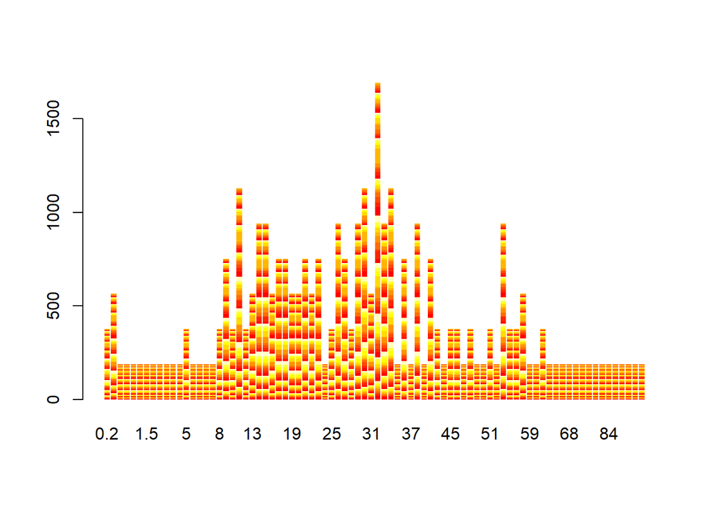

```r
tab <- table(Age1_2)
barplot(tab, col = heat.colors(10), border = NA)
```

J’essaye de faire un tableau avec ce Age1_2 que j’ai obtenu précédemment.